# Composition Analysis of Fennica dated 2025-12-03

# Overall summary

1,264,270 records and 173,307,233 attribute values in total. Constituent files:

- data/fennica/fennica.parquet (392MB)

## Temporal overview

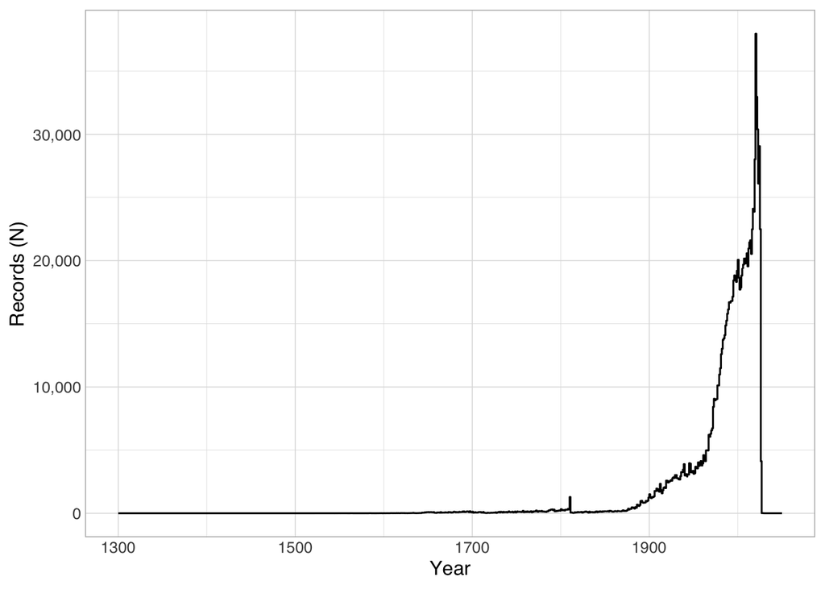

530 records do not have easily parseable dates between the years 1000 and 2050.

## Language overview

| [] | Records (N) | Proportion (%) |
| --- | --- | --- |
| fin (Finnish) | 905834 | 0.716487775554272 |
| eng (English) | 155270 | 0.122813955879678 |
| swe (Swedish) | 135968 | 0.107546647472454 |
| lat (Latin) | 16976 | 0.0134275115283919 |
| ger (German) | 15682 | 0.012403995981871 |
| rus (Russian) | 5720 | 0.00452435002016974 |
| fre (French) | 4591 | 0.00363134457038449 |
| mul (Multiple languages) | 4548 | 0.00359733284820489 |
|  | 2970 | 0.00234918174124198 |
| est (Estonian) | 1782 | 0.00140950904474519 |

[output cut: 158 more lines]

# Field code usage overview

In total, 239 distinct fields are used.

Legend for the table below:

- `records`: how many records have at least one of this field
- `r_p`: the above as a percentage of all records
- `n`: the total number of appearances of this field
- `vals_per_rec`: calculated from the above, the mean number of appearances of this field per record
- `recs_with_mult_vals`: the number of records that have more than one repetition of this field

| field_code | field_description | records | r_p | n | vals_per_rec | recs_with_mult_vals |
| --- | --- | --- | --- | --- | --- | --- |
| <a name="001" href="https://www.loc.gov/marc/bibliographic/bd001.html">001</a> | Control Number | 1264270 | 1 | 1264270 | 1 | 0 |
| <a name="003" href="https://www.loc.gov/marc/bibliographic/bd003.html">003</a> | Control Number Identifier | 1264270 | 1 | 1264270 | 1 | 0 |
| <a name="005" href="https://www.loc.gov/marc/bibliographic/bd005.html">005</a> | Date and Time of Latest Transaction | 1264270 | 1 | 1264284 | 1.00001107358397 | 11 |
| <a name="006" href="https://www.loc.gov/marc/bibliographic/bd006.html">006</a> | Additional Material Characteristics | 110526 | 0.0874227815260981 | 110856 | 1.00298572281635 | 320 |
| <a name="007" href="https://www.loc.gov/marc/bibliographic/bd007.html">007</a> | Physical Description | 324348 | 0.256549629430422 | 367306 | 1.13244416490929 | 42804 |
| <a name="008" href="https://www.loc.gov/marc/bibliographic/bd008.html">008</a> | General Information | 1264269 | 0.999999209029717 | 1264269 | 1 | 0 |
| <a name="010" href="https://www.loc.gov/marc/bibliographic/bd010.html">010</a> | Library of Congress Control Number | 500 | 0.000395485141623229 | 502 | 1.004 | 2 |
| <a name="015" href="https://www.loc.gov/marc/bibliographic/bd015.html">015</a> | National Bibliography Number | 836348 | 0.661526414452609 | 1720837 | 2.05756096744417 | 835369 |
| <a name="016" href="https://www.loc.gov/marc/bibliographic/bd016.html">016</a> | National Bibliographic Agency Control Number | 1 | 7.90970283246458e-07 | 3 | 3 | 1 |
| <a name="017" href="https://www.loc.gov/marc/bibliographic/bd017.html">017</a> | Copyright or Legal Deposit Number | 1 | 7.90970283246458e-07 | 1 | 1 | 0 |

[output cut: 229 more lines]

# Field code usage overview by subfield

In total, 1,716 distinct field+subfield combinations are used.

Legend for the table below:

- `records`: how many records have at least one of this field+subfield
- `r_p`: the above as a percentage of all records
- `dist_vals`: the number of different values appearing in this field+subfield
- `e_vals`: at most seven random sample values of this field+subfield
- `n`: the total number of appearances of this field+subfield
- `vals_per_rec`: calculated from the above, the mean number of appearances of this field+subfield per record
- `recs_with_mult_vals`: the number of records that have more than one repetition of this field+subfield

| subfield_code | subfield_description | records | r_p | dist_vals | e_vals | n | vals_per_rec | recs_with_mult_vals |
| --- | --- | --- | --- | --- | --- | --- | --- | --- |
| [001: Control Number](https://www.loc.gov/marc/bibliographic/bd001.html) |  |  |  |  |  |  |  |  |
| 001$ | NA | 1,264,270 | 100% | 1,202,358 | 000891239 (1)\|002434484 (1)\|005521208 (1)\|000886802 (1)\|000832570 (3)\|005627616 (1)\|000626897 (1) | 1,264,270 | 1 | 0 |
| [003: Control Number Identifier](https://www.loc.gov/marc/bibliographic/bd003.html) |  |  |  |  |  |  |  |  |
| 003$ | NA | 1,264,270 | 100% | 1 | FI-MELINDA (1,264,270) | 1,264,270 | 1 | 0 |
| [005: Date and Time of Latest Transaction](https://www.loc.gov/marc/bibliographic/bd005.html) |  |  |  |  |  |  |  |  |
| 005$ | NA | 1,264,270 | 100% | 1,112,219 | 20230909214316.0 (1)\|20240130070344.0 (1)\|20250310175733.0 (1)\|20231009090507.0 (1)\|20250605163708.0 (1)\|20230917040724.0 (2)\|20250401172317.0 (1) | 1,264,284 | 1 | 11 |
| [006: Additional Material Characteristics](https://www.loc.gov/marc/bibliographic/bd006.html) |  |  |  |  |  |  |  |  |
| 006$ | NA | 110,526 | 8.74% | 402 | sar \| 0 b0 (1)\|m\|\|\|\|\|o\|\|\|\|\|\| (1)\|s n m 0 b0 (1)\|sa\|\| \| \|\|\|\|\|\|\|\|\|b0 (1)\|m\|\|\|\|\|\|\|\|\|\|\|\|\|\|\|\|\| (4)\|a\|\|\|\|\|s\|\|\|\|\|\|\|\| \|\| (1)\|sar \| \| \|1 b0 (1) | 110,856 | 1 | 320 |
| [007: Physical Description](https://www.loc.gov/marc/bibliographic/bd007.html) |  |  |  |  |  |  |  |  |
| 007$ | NA | 324,348 | 25.65% | 445 | cr\|\|\| \|\|\|\|\|\|\|\| (2,130)\|cr cza\|\|\|\|\|\|\|\| (1)\|cr \|\|\|\|\|\|m\|a\|\| (2)\|sd\|fs\|gl\|\|m\|\|\| (2)\|vd cvadz\| (1)\|cr c\|a\|\|\|\|\|\|\|\| (3)\|c\| \|g\|\|\|\|\|\|\|\|\| (1) | 367,306 | 1.13 | 42,804 |
| [008: General Information](https://www.loc.gov/marc/bibliographic/bd008.html) |  |  |  |  |  |  |  |  |
| 008$ | NA | 1,264,269 | 100% | 561,172 | 941012s1951 dk \|\|\|\|\|\|\|\|\|\|\|\|\|\|\|f\|dan\| (1)\|160323t20162016fi \|\|\|\|j \|0\| f\|fin\| (2)\|030721s2003 fi \|\|\|\|j\|\|\|\|\|\|\|\|\|\|0\|fin\| (1)\|981002s1998 fi \|\|\|\|\|\|\|\|\|\|… | 1,264,269 | 1 | 0 |
| [010: Library of Congress Control Number](https://www.loc.gov/marc/bibliographic/bd010.html) |  |  |  |  |  |  |  |  |
| 010$a | LC control number | 500 | 0.04% | 480 | 92134517 (1)\|85132734 (1)\|ltf91063557 (1)\|84106459 (2)\|72324194 (1)\|86149334 (2)\|72326277 (1) | 500 | 1 | 0 |
| 010$z | Cancelled/invalid LC control number | 2 | 0% | 2 | ltf91081499 (1)\|ltf91081402 (1) | 2 | 1 | 0 |
| [015: National Bibliography Number](https://www.loc.gov/marc/bibliographic/bd015.html) |  |  |  |  |  |  |  |  |
| 015$2 | NA | 834,870 | 66.04% | 9 | sti (3)\|1440376397 (1)\|nor (1)\|skl UUSI (1)\|kl (2)\|ykl (3)\|skl (842,304) | 842,317 | 1.01 | 7,292 |
| 015$a | National bibliography number | 836,348 | 66.15% | 798,965 | fx780401 (1)\|f486311 (1)\|fd2020-00026208 (1)\|fx964176 (1)\|f435174 (1)\|f20120729 (1)\|fac008071 (2) | 843,961 | 1.01 | 7,429 |
| 015$g | NA | 1 | 0% | 1 | pehmeäkantinen (1) | 1 | 1 | 0 |
| 015$q | NA | 34,170 | 2.7% | 68 | kovakantibnen (1)\|C-kasetti (343)\|kansio (24)\|kovakantinen, vaaleansinikantinen (1)\|2. p. (1)\|vihkiraamattu, pellavakantinen, lyhyt risti, kovakantinen (1)\|taitelehti (2) | 34,553 | 1.01 | 376 |
| 015$z | NA | 5 | 0% | 5 | fv10700 (1)\|fac013280 (1)\|f517909 (1)\|952-453-054-6 (1)\|978-952-9802-79-1 (1) | 5 | 1 | 0 |
| [016: National Bibliographic Agency Control Number](https://www.loc.gov/marc/bibliographic/bd016.html) |  |  |  |  |  |  |  |  |
| 016$2 | Source | 1 | 0% | 1 | Uk (1) | 1 | 1 | 0 |
| 016$Y | NA | 1 | 0% | 1 | 7 (1) | 1 | 1 | 0 |
| 016$a | Record control number | 1 | 0% | 1 | 020691326 (1) | 1 | 1 | 0 |
| [017: Copyright or Legal Deposit Number](https://www.loc.gov/marc/bibliographic/bd017.html) |  |  |  |  |  |  |  |  |
| 017$a | Copyright registration number | 1 | 0% | 1 | TKK-DISS-1987 (1) | 1 | 1 | 0 |
| [https://www.kansalliskirjasto.fi/extra/marc21/bib/omat.htm#019\|019: FINUC-TUNNUS\|OCLC Control Number Cross-Reference](http://www.oclc.org/bibformats/en/0xx/019.html) |  |  |  |  |  |  |  |  |
| 019$9 | NA | 1 | 0% | 1 | FENNI<DROP> (1) | 1 | 1 | 0 |
| 019$a | NA | 37 | 0% | 34 | fs351515 (1)\|fs371520 (1)\|fs025716 (1)\|fs052786 (1)\|fs174243 (1)\|fs495745 (1)\|f413233 (1) | 37 | 1 | 0 |

[output cut: 1925 more lines]